# EC349 Seminar 2 New Markdown

2023-11-02

#### Instruction:

1. Create a R Markdown document
2. Follow [this link](https://www.markdownguide.org/basic-syntax/) for help with basic R syntax OR copy and past this URL in your browser: https://www.markdownguide.org/basic-syntax/
3. Follow [this link](https://markdownguide.offshoot.io/extended-syntax/#automatic-url-linking) to help with extended R syntax OR copy and past this URL in your browser: https://markdownguide.offshoot.io/extended-syntax/#automatic-url-linking
4. Answer all questions.
5. Write out each question and provide the solution immediately after using a title “**Answer**”.
   - You can copy the question directly from this document.
   - Be sure to provide an explanation of your code where relevant.
6. Upload your Markdown file to your GitHub account.
7. Provide the link to the GitHub document
8. Convert your output to a PDF document and submit on Moodle.

Complete the following:

> 1. Write your name and surname in bold font, with your Name ONLY in italics.

```
Answer Below
```

*Hanjun* **Jin**

> 2. Print your student number and what year you are in on different lines.

```
Answer Below
```

```r
print(2105015)
```

```
## [1] 2105015
```

```r
print("Year 3")
```

```
## [1] "Year 3"
```

> 3. Briefly state, in italics, why you are doing this Data Science Module

```
Answer Below
```

*I thought it would be helpful*

> 4. Make an unordered list of at least 3 things you have learned in this module.

```
Answer Below
```

- git
- github
- r
> 5. Create a table showing the 1st 5 stages of the John Rollins General Data Science Methodology and the quetions associate with them.

```
Answer Below
```

| John Rollins General Data Science Methodology Stages | Questions |
| --- | --- |
| Business/Problem Understanding | What problem/question are you trying to solve/answer? |
| Analytic Approach | How can you use data to answer this question? |
| Data Requirements | What data is needed to answer the question? |
| Data Collection | What is the source of the data? How will you collect & receive it? |
| Data Understanding | Is the data indicative of the problem to be solved? |

> 6. Create an ordered list of at least 3 other Data Science methodologies.

```
Answer Below
```

1. Crisp-dm
2. SEMMA
3. KDD
> 7. Provide and ordered list the weaknesses of the CRISP-DM methodology and how to address them

```
Answer Below
```

1. Outdated -> Add phases (if needed) and define the sub items within each phase
2. Documentation Heavy -> Document enough… but not too much
3. Not a Project Management Approach -> Combine with a team coordination process and Define team roles
4. Can Ignore Stakeholders -> Ensure actionable insight
5. Slow Start -> Iterate quickly
> 8. Download and include a University of Warwick Logo in your document.

```
Answer Below
```

[figure not shown]

> 9. Write and execute a code to randomly generate 10 numbers from a normal distribution with mean 12 and standard deviation 3.

```
Answer Below
```

```r
rnorm(10, mean = 12, sd= 3)
```

```
##  [1] 15.777086 11.171760 11.056459  6.015968  5.658883 11.626756 11.257600
##  [8] 10.499665 11.323212  8.231655
```

> 10. Write and execute a code to calculate the mean of 12 random numbers generated from the interval of integers from 5 to 25.

```
Answer Below
```

```r
mean(sample(5:25, 12))
```

```
## [1] 16.16667
```

```r
mean(runif(12, min=5, max=25))
```

```
## [1] 13.78565
```

> 11. Write and execute a code to create a scatter plot containing 12 points whose coordinates were randomly geenrated in the interval 5 to 25. Provide a title for the figure, label the x and y axis.

```
Answer Below
```

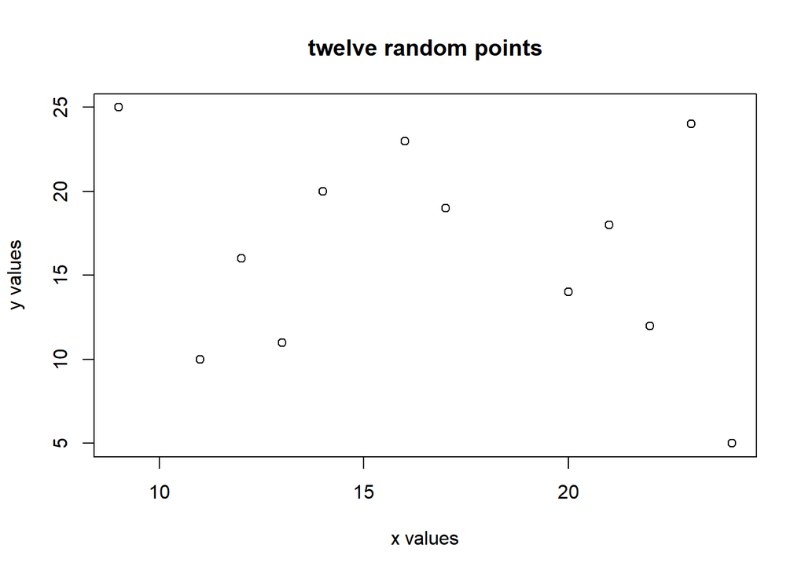

```r
plot(x=sample(5:25,12), y=sample(5:25, 12), main="twelve random points", xlab="x values", ylab="y values")
```

> 12. Write and execute a code to create a function to calculate standard error. Then, calculate the standard error of a set of 15 randomly generated numbers from a normal distribution with mean 12 and standard deviation 3.

```
Answer Below
```

```r
exists("se")
```

```
## [1] FALSE
```

```r
se <-function(a) {
  x<- var(a)
  y<- length(a)
  return(sqrt(x/y))
}
testEg <- rnorm(15, mean = 12, sd =3)
se(testEg)
```

```
## [1] 0.91924
```

> 13. Given that BMI=kg/m2, where kg is the person’s weight in kilograms and m2is height in meters squared, write and execute a code to create a function that calculates the BMI of who weighs 85kg and is 1.9m tall.

```
Answer Below
```

```r
exists("bmi")
```

```
## [1] FALSE
```

```r
bmi <- function(weightInKG,heightInMetres) {
  return (weightInKG/heightInMetres^2)
}
bmi(85, 1.9)
```

```
## [1] 23.54571
```